# Arch & Garch in R

### Modelling phase

The exploratory insights seem to suggest that there is ARCH effects present but, I’ll work to formalize this intuition. Additionally, there are a few other questions to review as well.

#### Is the expected log-return zero?

I suggested that the log returns did not appear significantly different from zero when reviewing the density plots. A formal t-test below confirms this given the low t-statistic and accompanying high p-value.

```r
t.test(x = spdr_etf$log_return, conf.level = .95) %>%
  tidy() %>%
  custom_kable()
```

| estimate | statistic | p.value | parameter | conf.low | conf.high | method | alternative |
| --- | --- | --- | --- | --- | --- | --- | --- |
| 7.25e-05 | 0.2651483 | 0.7909168 | 2534 | -0.0004634 | 0.0006083 | One Sample t-test | two.sided |

#### Are there any serial correlations in the log returns?

To review if the log returns have any serial auto-correlation, I’ve developed an ACF plot below. There are numerous significant spikes across the series indicating that there does appear to be auto-correlation.

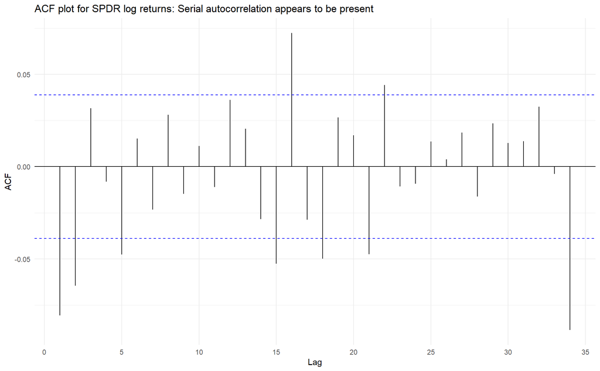

```r
ggAcf(x = spdr_etf$log_return) +
  ggtitle("ACF plot for SPDR log returns: Serial autocorrelation appears to be present")
```

A Box-Ljung test confirms this. The test statistic is very high, which results in the low p-value. The null hypothesis can be rejected here indicating that there is serial auto-correlation.

```r
Box.test(x = spdr_etf$log_return, lag = 10, type = "Ljung") %>%
  tidy() %>%
  custom_kable()
```

| statistic | p.value | parameter | method |
| --- | --- | --- | --- |
| 40.38014 | 1.45e-05 | 10 | Box-Ljung test |

#### Is there ARCH effect in the log-returns?

To check for arch effects, I’ll use two methods. The first is a Box-Ljung with the centred and squared log returns. As seen, the test is significant indicating that ARCH effects are present.

```r
spdr_etf <- spdr_etf %>%
  mutate(arch_test = log_return - mean(log_return))

Box.test(x = spdr_etf$arch_test ^ 2, lag = 10, type = "Ljung") %>%
  tidy() %>%
  custom_kable()
```

| statistic | p.value | parameter | method |
| --- | --- | --- | --- |
| 1895.304 | 0 | 10 | Box-Ljung test |

The second is Engle’s ARCH test, which I’ve loaded below (`archTest`). The key feature to review here is the model’s p-value, which signals that there is a significant ARCH effect.

```r
archTest <- function(rtn, m = 10){
  # Perform Lagrange Multiplier Test for ARCH effect of a time series
  # rtn: time series
  # m: selected AR order
  #
  y=(rtn-mean(rtn))^2
  T=length(rtn)
  atsq=y[(m+1):T]
  x=matrix(0,(T-m),m)
  for (i in 1:m){
    x[,i]=y[(m+1-i):(T-i)]
  }
  md=lm(atsq~x)
  summary(md)
}

archTest(rtn = spdr_etf$log_return, m = 10)
```

```
##
## Call:
## lm(formula = atsq ~ x)
##
## Residuals:
##        Min         1Q     Median         3Q        Max
## -0.0041924 -0.0000982 -0.0000494  0.0000156  0.0150562
##
## Coefficients:
##               Estimate Std. Error t value Pr(>|t|)
## (Intercept)  3.773e-05  1.262e-05   2.990  0.00282 **
## x1          -2.762e-03  1.977e-02  -0.140  0.88892
## x2           3.325e-01  1.963e-02  16.940  < 2e-16 ***
## x3          -1.520e-02  2.068e-02  -0.735  0.46259
## x4          -1.425e-02  2.066e-02  -0.690  0.49047
## x5           1.533e-01  2.047e-02   7.488 9.60e-14 ***
## x6           9.943e-02  2.049e-02   4.854 1.29e-06 ***
## x7           4.658e-02  2.058e-02   2.263  0.02370 *
## x8          -5.128e-02  2.060e-02  -2.489  0.01287 *
## x9           1.180e-01  1.956e-02   6.033 1.85e-09 ***
## x10          1.300e-01  1.969e-02   6.604 4.88e-11 ***
## ---
## Signif. codes:  0 '***' 0.001 '**' 0.01 '*' 0.05 '.' 0.1 ' ' 1
##
## Residual standard error: 0.0005718 on 2514 degrees of freedom
## Multiple R-squared:  0.2837, Adjusted R-squared:  0.2808
## F-statistic: 99.55 on 10 and 2514 DF,  p-value: < 2.2e-16
```

#### Fit Gaussian ARMA-GARCH model for the log-return series (GARCH(2,1)). Perform model checking. Obtain the QQ-plot of the standardized residuals. Write down the fitted model

To model log return volatility, I’ve developed a GARCH (2, 1) below. Not all of the coefficients are significant, which is one downside of the model. The alpha one value ($\alpha_1$) below $\frac{1}{3}$ also highlights the series has a high kurtosis. The most important summaries here are the Ljung-Box tests. Specifically, the $R^2$ tests show high p-values indicating the GARCH model captures the series volatility correctly. Since the main concern here is modelling volatility structure, this is positive. Overall, the model is a reasonable composition.

```r
spdr_garch <- garchFit(~1 + garch(2, 1), data = spdr_etf$log_return, trace = F)

summary(spdr_garch)
```

```
##
## Title:
##  GARCH Modelling
##
## Call:
##  garchFit(formula = ~1 + garch(2, 1), data = spdr_etf$log_return,
##     trace = F)
##
## Mean and Variance Equation:
##  data ~ 1 + garch(2, 1)
## <environment: 0x000000001ba0b9f0>
##  [data = spdr_etf$log_return]
##
## Conditional Distribution:
##  norm
##
## Coefficient(s):
##         mu       omega      alpha1      alpha2       beta1
## 5.7243e-04  2.3226e-06  1.9896e-03  1.1165e-01  8.7049e-01
##
## Std. Errors:
##  based on Hessian
##
## Error Analysis:
##         Estimate  Std. Error  t value Pr(>|t|)
## mu     5.724e-04   1.707e-04    3.353   0.0008 ***
## omega  2.323e-06   4.938e-07    4.704 2.56e-06 ***
## alpha1 1.990e-03   1.031e-02    0.193   0.8469
## alpha2 1.117e-01   1.691e-02    6.604 4.01e-11 ***
## beta1  8.705e-01   1.457e-02   59.730  < 2e-16 ***
## ---
## Signif. codes:  0 '***' 0.001 '**' 0.01 '*' 0.05 '.' 0.1 ' ' 1
##
## Log Likelihood:
##  7976.237    normalized:  3.146445
##
## Description:
##  Sat Mar 02 22:24:26 2019 by user: Mark
##
##
## Standardised Residuals Tests:
##                                 Statistic p-Value
##  Jarque-Bera Test   R    Chi^2  341.8337  0
##  Shapiro-Wilk Test  R    W      0.9847918 7.758679e-16
##  Ljung-Box Test     R    Q(10)  16.68652  0.08159467
##  Ljung-Box Test     R    Q(15)  23.20357  0.07991225
##  Ljung-Box Test     R    Q(20)  27.01178  0.1349328
##  Ljung-Box Test     R^2  Q(10)  7.011437  0.7243648
##  Ljung-Box Test     R^2  Q(15)  8.756466  0.8899028
##  Ljung-Box Test     R^2  Q(20)  9.758849  0.9723368
##  LM Arch Test       R    TR^2   7.741879  0.8049624
##
## Information Criterion Statistics:
##       AIC       BIC       SIC      HQIC
## -6.288944 -6.277430 -6.288952 -6.284767
```

As specified, the GARCH model can be written as:

**GARCH Model:**

$r_t = \mu + \alpha_t$

$\alpha_t = \sigma_t \epsilon_t$

$\sigma{^2}{_t} = \alpha_0 + \alpha_1 a{^2}_{t - 1} + \alpha_2 a{^2}_{t - 2} + \beta_1 \sigma{^2}_{t - 1}$

The values for these model parameters can be found below. As a note, $\alpha_0$ is coded as omega:

```r
spdr_garch@fit$coef %>%
  round(7) %>%
  custom_kable()
```

| mu | 0.0005724 |
| --- | --- |
| omega | 0.0000023 |
| alpha1 | 0.0019896 |
| alpha2 | 0.1116523 |
| beta1 | 0.8704859 |

Reviewing the residuals, there appears to be some serial auto-correlation but, it might not be significant across 35 lags here. There is a very large spike at lag 1 but, this is the only significant lag.

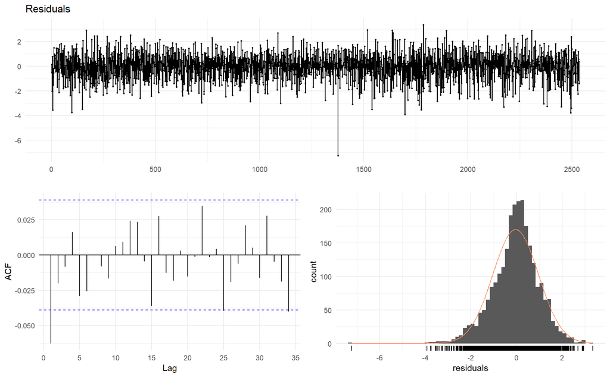

```r
garch_residuals <- residuals(object = spdr_garch, standardize = T)

checkresiduals(garch_residuals)
```

The strength of evidence in the Ljung-Box test for the residuals is right around .05. With the added fitted degrees of freedom, it’s below. This is a judgement call but, they appear normal enough I think.

```r
Box.test(x = garch_residuals, lag = 35, fitdf = 5, type = "Ljung") %>%
  tidy() %>%
  custom_kable()
```

| statistic | p.value | parameter | method |
| --- | --- | --- | --- |
| 44.70226 | 0.0411343 | 30 | Box-Ljung test |

The QQ plot for the residuals shows heavier tails, specifically on the left side of the distribution. This indicates that the fitted values over and underestimate the actual log returns. Under the circumstances, this is expected because the series has fat tails stemming from a heavy Leptokurtic distribution.

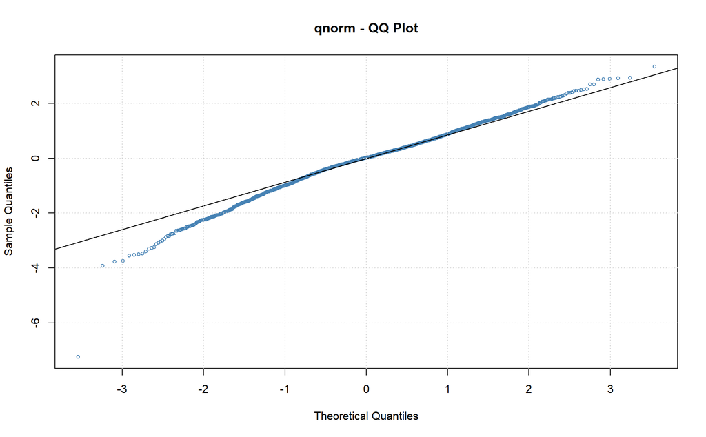

```r
plot(spdr_garch, which = 13)
```

#### Build an ARMA-GARCH model with Student t innovations for the log-return series. Perform model checking and write down the fitted model.

Switching up the model slightly, I’ve developed a second GARCH (2, 1) but, included student t innovations to account for the fat tails.As before, the most important summaries here are the Ljung-Box tests. They all show show high p-values indicating the GARCH model captures the series volatility correctly.

```r
spdr_garch_t <- garchFit(~1 + garch(2, 1),
                         data = spdr_etf$log_return,
                         trace = F,
                         cond.dist = "std")

summary(spdr_garch_t)
```

```
##
## Title:
##  GARCH Modelling
##
## Call:
##  garchFit(formula = ~1 + garch(2, 1), data = spdr_etf$log_return,
##     cond.dist = "std", trace = F)
##
## Mean and Variance Equation:
##  data ~ 1 + garch(2, 1)
## <environment: 0x000000001b296320>
##  [data = spdr_etf$log_return]
##
## Conditional Distribution:
##  std
##
## Coefficient(s):
##         mu       omega      alpha1      alpha2       beta1       shape
## 7.2454e-04  1.5793e-06  6.1117e-03  1.1435e-01  8.7418e-01  7.5068e+00
##
## Std. Errors:
##  based on Hessian
##
## Error Analysis:
##         Estimate  Std. Error  t value Pr(>|t|)
## mu     7.245e-04   1.613e-04    4.493 7.01e-06 ***
## omega  1.579e-06   4.988e-07    3.166  0.00155 **
## alpha1 6.112e-03   1.272e-02    0.480  0.63094
## alpha2 1.143e-01   2.086e-02    5.482 4.21e-08 ***
## beta1  8.742e-01   1.629e-02   53.657  < 2e-16 ***
## shape  7.507e+00   1.137e+00    6.604 4.00e-11 ***
## ---
## Signif. codes:  0 '***' 0.001 '**' 0.01 '*' 0.05 '.' 0.1 ' ' 1
##
## Log Likelihood:
##  8015.731    normalized:  3.162024
##
## Description:
##  Sat Mar 02 22:24:29 2019 by user: Mark
##
##
## Standardised Residuals Tests:
##                                 Statistic p-Value
##  Jarque-Bera Test   R    Chi^2  484.6936  0
##  Shapiro-Wilk Test  R    W      0.982789  0
##  Ljung-Box Test     R    Q(10)  16.4353   0.08783114
##  Ljung-Box Test     R    Q(15)  22.44416  0.09667569
##  Ljung-Box Test     R    Q(20)  26.27182  0.1570209
##  Ljung-Box Test     R^2  Q(10)  5.461128  0.8583262
##  Ljung-Box Test     R^2  Q(15)  7.906807  0.9274645
##  Ljung-Box Test     R^2  Q(20)  9.649639  0.9740892
##  LM Arch Test       R    TR^2   6.005807  0.9157891
##
## Information Criterion Statistics:
##       AIC       BIC       SIC      HQIC
## -6.319314 -6.305497 -6.319326 -6.314302
```

As specified, the GARCH model can be written as:

**GARCH Model: Epsilon has t distribution**

$r_t = \mu + \alpha_t$

$\alpha_t = \sigma_t \epsilon_t$

$\sigma{^2}{_t} = \alpha_0 + \alpha_1 a{^2}_{t - 1} + \alpha_2 a{^2}_{t - 2} + \beta_1 \sigma{^2}_{t - 1}$

The values for these model parameters can be found below.

```r
spdr_garch_t@fit$coef %>%
  round(7) %>%
  custom_kable()
```

| mu | 0.0007245 |
| --- | --- |
| omega | 0.0000016 |
| alpha1 | 0.0061117 |
| alpha2 | 0.1143458 |
| beta1 | 0.8741839 |
| shape | 7.5067540 |

The residuals appear to be similar to the previous model but, with a wider range. The ACF still appears borderline with serial auto-correlation.

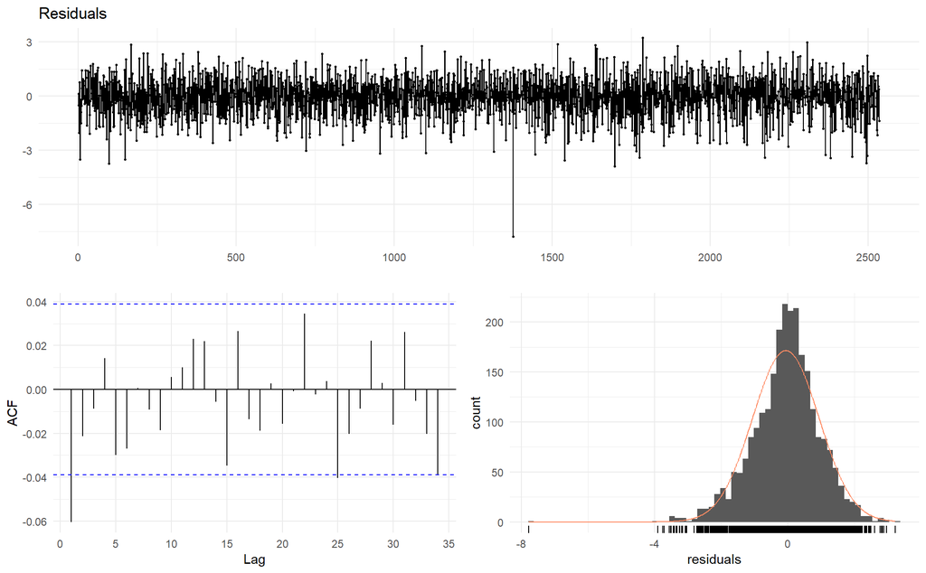

```r
garch_t_residuals <- residuals(object = spdr_garch_t, standardize = T)

checkresiduals(garch_t_residuals)
```

Again, the test is around .05 when rounding up.

```r
Box.test(x = garch_t_residuals, lag = 35, fitdf = 5, type = "Ljung") %>%
  tidy() %>%
  custom_kable()
```

| statistic | p.value | parameter | method |
| --- | --- | --- | --- |
| 44.13562 | 0.0463596 | 30 | Box-Ljung test |

The QQ plot for the residuals shows that the tails in this model are more normal than the Gaussian innovation model (save for a few outliers). This correction shows that the model is closer to the linear ideal given the residuals are normal IID. Given this, I think the student t innovation model is preferable here.

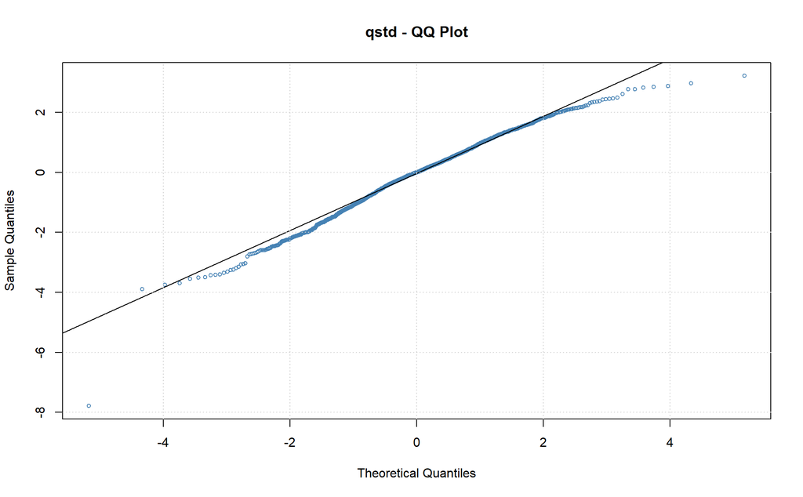

```r
plot(spdr_garch_t, which = 13)
```